# LARR Data Pages

Carwil Bjork-James

10/12/2021

This Rmarkdown script uses the following libraries. You may need to run one of the two scripts `install-packages.R` or `install-common-packages.R` first if these packages aren’t already loaded into RStudio. (Both scripts do the same thing, but `install-packages.R` is written in a more elegant way.)

```r
library(googlesheets4)
library(googledrive)
library(tidyr)
library(readr)
library(plyr) # should be invoked before dplyr
library(dplyr)
library(stringr)
library(reactable)
library(forcats)
library(ggplot2)
library(ggtext)
library(ggalluvial)
library(skimr)
library(stringr)
library(janitor) # for tabyl
library(flextable)
library(scales)
library(GGally)
library(webshot)
library(magick)
library(knitr)
library(kableExtra)
library(forcats)
library(ggfittext)
library(hrbrthemes)
library(janitor)
```

# First, import the data from Google Sheets

*We’ve already used this chunk of code before over in `Database Overview.Rmd`, but I’m giving a walk-through of how it works, bit-by-bit.*

In order for this to work, you must have the “Bolivia Deaths Database” in the root directory of your Google Drive. You must also accept giving “Tidyverse API” access to your Google Drive.

This code segment applies a set of standard filters:

- Culling out currently inactive variables using `select`
- Segmenting out parenthetical annotations using `separate`: `Answer (explanation)` is split into two separate variables, the first holding a categorical variable, and the second holding the corresponding notes.
- **Filtering, using `filter`, to remove the following cases:**
  - `unconfirmed` is a flag for deaths in range of death totals. So if there were “five to eight people killed,” the last three deaths have TRUE in `unconfirmed`.
  - We also filter out “Collateral” and “Nonconflict Accident” cases in `Intentionality`. These cases are both peripheral to some of the purposes of the database. Significantly for comparisons over the long-term, we think that these kinds of deaths are unevenly distributed over time.

We also import a basic table of presidential terms from the database.

```r
live.import <- FALSE

de.filename <- "data/deaths-entries.rds"
pt.filename <- "data/presidents-table.rds"
use.current.archive <- TRUE # This flag should be set to true when
                            # the above filenames do not have a date

if (live.import){
  # Import the Entries
  source("src/import-deaths-database.R")
  source("src/update-versioned-archive.R")
  de <- import_deaths_database(incl_inactive=FALSE, incl_narrative=FALSE,
                               parse_parenthical=TRUE)

  #
  # Save current version of the file to data/
  #
  #
  de.filename.dated <- update_versioned_archive(de, de.filename)

  # Import the presidents table
  pt <- import_presidents_table()
  pt.filename.dated <- update_versioned_archive(pt, pt.filename)

}else
{
  de <- read_rds(de.filename)
  pt <- read_rds(pt.filename)

    if(use.current.archive){ # if the filenames are undated,
                           # use the most recent archived file as
                           # the file name in question
                           #
                           # (potential future upgrade: check that the
                           # undated file contains the same data as this file)
    filelist <-file.info(list.files(path="data", pattern="deaths-entries-.*"), extra_cols = FALSE)
    filelist <- filelist[with(filelist, order(as.POSIXct(mtime))), ]
    files <- rownames(filelist)
    de.filename.dated <- paste("data/", tail(files, 1), sep="")

    filelist <-file.info(list.files(path="data", pattern="presidents-table-.*"), extra_cols = FALSE)
    filelist <- filelist[with(filelist, order(as.POSIXct(mtime))), ]
    files <- rownames(filelist)
    pt.filename.dated <- paste("data/", tail(files, 1), sep="")
    }
}

de.imported <- de # keep a copy around for debugging

# de <- def # AUTOFILTERING. Comment out when we want to consider the whole dataset
          # Also, eventually we may want to handle "unconfirmed" in a more complex way
          #   At that point, we will no longer filter for it, but pass it through.


# clean up the variable names
pt <- rename_with(pt, ~ sub(" \\(.*", "", .x))
pt <- rename_with(pt, ~ tolower(gsub(" ", "_", .x, fixed = TRUE)))
pt <- rename_with(pt, ~ gsub("frequency_of_", "", .x, fixed = TRUE))
pt <- rename_with(pt, ~ gsub("-", "_", .x, fixed = TRUE))
pt <- rename_with(pt, ~ gsub("/", "_", .x, fixed = TRUE))
pt <- rename_with(pt, ~ gsub("?", "", .x, fixed = TRUE))

# return the list to verify the cleaning worked
# glimpse(pt2)

# create a smaller presidents table just for the study period
studyperiod.start <- as.Date("1982-10-10")
studyperiod.end <- Sys.Date()
pt.study <- pt %>% filter((first_day >= studyperiod.start) & (last_day <= studyperiod.end))

datafiles_footer <- function(de=TRUE, pt=FALSE, es=FALSE){
  datafile_text <- ""
  if(de){
    datafile_text <- paste(datafile_text, "**Entries:**", de.filename.dated, sep=" ")
  }

  if(pt){
    datafile_text <- paste(datafile_text, "**Presidents:**", pt.filename.dated, sep=" ")
  }

  if(es){
    datafile_text <- paste(datafile_text, "**Event Status:**", es.filename.dated, sep=" ")
  }

  str_trim(datafile_text)
}
```

# Next, process the variables

First, we want to think through which variables are involved. They are:

- `pres_admin` — who was the president?
- `protest_domain` — The broad arena of politial conflict. Tells us whether to count something as a coca death, or an armed actor death
- `state_perpetrator` — Was this death perpetrated by the state?

These are standard blocks of code, which currently appear in Database Overview.Rmd, and eventually will find a home in a variable set-up function. What does this code do?

```r
library(janitor) # for tabyl

## Factoring: Presidential administration

president_levels <- c(
  "Hernán Siles Zuazo", "Víctor Paz Estenssoro", "Jaime Paz Zamora",
  "Gonzalo Sanchez de Lozada (1st)", "Hugo Banzer (2nd)", "Jorge Quiroga",
  "Gonzalo Sanchez de Lozada (2nd)", "Carlos Diego Mesa Gisbert",
  "Eduardo Rodríguez", "Evo Morales", "Interim military government",
  "Jeanine Áñez", "Luis Arce") # All presidencies, in chronological order
president_initials <- c(
  "HSZ", "VPE", "JPZ",
  "GSL", "HB", "JQ",
  "GSL", "CM",
  "ER", "EM", "Mil",
  "JA", "LA")

de <- de %>% mutate(pres_admin=factor(pres_admin, levels=president_levels))
de %>% tabyl(pres_admin)  %>%
  adorn_totals("row") %>%
  adorn_pct_formatting()
```

```
##                       pres_admin   n percent
##               Hernán Siles Zuazo   8    1.3%
##            Víctor Paz Estenssoro  43    6.7%
##                 Jaime Paz Zamora  21    3.3%
##  Gonzalo Sanchez de Lozada (1st)  51    8.0%
##                Hugo Banzer (2nd) 121   18.9%
##                    Jorge Quiroga  33    5.2%
##  Gonzalo Sanchez de Lozada (2nd) 146   22.8%
##        Carlos Diego Mesa Gisbert  19    3.0%
##                Eduardo Rodríguez   0    0.0%
##                      Evo Morales 148   23.2%
##      Interim military government   9    1.4%
##                     Jeanine Áñez  26    4.1%
##                        Luis Arce  14    2.2%
##                            Total 639  100.0%
```

```r
## Factoring: State perpetrator (a quasilogical variable)
de %>% tabyl(state_perpetrator)  %>%
  adorn_totals("row") %>%
  adorn_pct_formatting()
```

```
##  state_perpetrator   n percent valid_percent
##           Disputed   4    0.6%          0.6%
##          In mutiny   5    0.8%          0.8%
##           Indirect  15    2.3%          2.4%
##          Likely no   3    0.5%          0.5%
##         Likely Yes   4    0.6%          0.6%
##                 No 281   44.0%         45.3%
##       Presumed yes   2    0.3%          0.3%
##       Presumed Yes   7    1.1%          1.1%
##            Unknown   1    0.2%          0.2%
##                Yes 298   46.6%         48.1%
##               <NA>  19    3.0%             -
##              Total 639  100.0%        100.0%
```

```r
de$state_perpetrator <- fct_explicit_na(de$state_perpetrator, na_level = "Unknown")
de$state_perpetrator <- fct_collapse(de$state_perpetrator,
                                     Yes = c("Yes", "Likely Yes", "Presumed Yes", "Presumed yes"),
                                     Indirect = c("Indirect"),
                                     No = c("No", "Likely no"),
                                     Mutiny = c("In mutiny"),
                                     Unknown  = c("Unknown", "Disputed", "Suspected") )
de$state_perpetrator <- fct_relevel(de$state_perpetrator,
                                    c("Unknown", "No", "Indirect", "In mutiny", "Yes"))
de %>% tabyl(state_perpetrator)  %>%
  adorn_totals("row") %>%
  adorn_pct_formatting()
```

```
##  state_perpetrator   n percent
##            Unknown  24    3.8%
##                 No 284   44.4%
##           Indirect  15    2.3%
##                Yes 311   48.7%
##             Mutiny   5    0.8%
##              Total 639  100.0%
```

```r
## Factoring: State perpetrator (a categorical variable)
de.imported %>% tabyl(state_responsibility)  %>%
  adorn_totals("row") %>%
  adorn_pct_formatting() # Look at it before
```

```
##                             state_responsibility   n percent valid_percent
##                                 Political victim   2    0.3%          0.3%
##         Political victim / political perpetrator   1    0.2%          0.2%
##           Political victim / unknown perpetrator   3    0.5%          0.5%
##                              Separate from state 193   30.2%         31.2%
##                       State indirect perpetrator   3    0.5%          0.5%
##                                   State involved  46    7.2%          7.4%
##                         State likely perpetrator   5    0.8%          0.8%
##                                State perpetrator 291   45.5%         47.0%
##        State perpetrator, State victim in mutiny   9    1.4%          1.5%
##  State perpetrator, State victim refusing orders   1    0.2%          0.2%
##                                     State victim  60    9.4%          9.7%
##        State victim, State perpetrator in mutiny   5    0.8%          0.8%
##                                             <NA>  20    3.1%             -
##                                            Total 639  100.0%        100.0%
```

```r
# This code lets us look ta relevant cases of unintential death
#
# de %>% filter((intentionality=="Conflict Accident")|(intentionality=="Nonconflict Accident")|
#                 (intentionality=="Incidental")) -> de.acc
#
# de.acc %>% tabyl(state_responsibility)
# de.acc %>% filter(state_responsibility=="Victim")

de <- de %>% mutate(state_responsibility = case_when(    # overwrite the state responsibility for unintentional cases
                                   intentionality == "Incidental" ~ "Incidental",
                                   intentionality == "Conflict Accident" ~ "Accidental",
                                   TRUE ~ state_responsibility))

de$state_responsibility <- fct_explicit_na(de$state_responsibility, na_level = "Unknown")
de$state_responsibility <- fct_collapse(de$state_responsibility,
                             Perpetrator = c("State perpetrator", "State likely perpetrator",
                                             "State perpetrator, State victim refusing orders",
                                             "State perpetrator, State victim in mutiny",
                                             "State indirect perpetrator"),
                             Involved = c("State involved", "Political victim",
                                          "Political victim / political perpetrator",
                                          "Political victim / unknown perpetrator",
                                          "Possibly state involved"),
                             Victim = c("State victim",
                                        "State victim, State perpetrator in mutiny"),
                             Separate = c("Separate from state"),
                             Unintentional = c("Incidental", "Accidental"),
                             Unknown  = c("Unknown", "Unclear") )
sr_levels <- c("Perpetrator", "Victim", "Involved", "Separate", "Unintentional", "Unknown")
de$state_responsibility <- fct_relevel(de$state_responsibility, sr_levels)

state_resp.colors <-  c(
  Perpetrator = "forestgreen",
  Victim = "firebrick4",
  Involved = "lightgreen",
  Separate = "goldenrod2",
  Unintentional = "darkgray",
  Unknown = "lightgray")

de %>% tabyl(state_responsibility)  %>%
  adorn_totals("row") %>%
  adorn_pct_formatting() # Look at it after
```

```
##  state_responsibility   n percent
##           Perpetrator 307   48.0%
##                Victim  63    9.9%
##              Involved  28    4.4%
##              Separate 187   29.3%
##         Unintentional  36    5.6%
##               Unknown  18    2.8%
##                 Total 639  100.0%
```

Note that this leaves us with two variables for understanding the state’s role.

The “standard filters” on the dataset

```r
def <- de %>%
  filter(is.na(unconfirmed) | unconfirmed != TRUE) %>%
  filter(is.na(intentionality) | intentionality != "Collateral") %>%
  filter(is.na(intentionality) | intentionality != "Nonconflict Accident") %>%
  filter(is.na(intentionality) | intentionality != "Nonconflict")

de.confirmed <- def
```

# Replicating the Document

## 1st Text Section: An overall breakdown

```r
n_entries <- count(de)
n_confirmed <- count(def)

n_unconfirmed <- sum(de$unconfirmed == TRUE, na.rm =TRUE)

de_excluded <- de %>%
  filter(intentionality == "Collateral"
         | intentionality == "Nonconflict Accident"
         | intentionality == "Nonconflict")
n_excluded <- count(de_excluded)
n_collateral <- sum(de$intentionality == "Collateral", na.rm = TRUE)
n_nonconfaccident <- sum(de$intentionality == "Nonconflict Accident", na.rm = TRUE)
n_nonconfdeath <- sum(de$intentionality == "Nonconflict", na.rm = TRUE)

de_named <- de %>%
  filter(!is.na(dec_firstname) | !is.na(dec_surnames) )
n_named <- count(de_named)
```

### Summarizing intentionality

First, a frequency table. For now, we’re printing this table in two formats. The plot/webshot method can be embedded in a GitHub document, while the kable can only be seen in an html document.

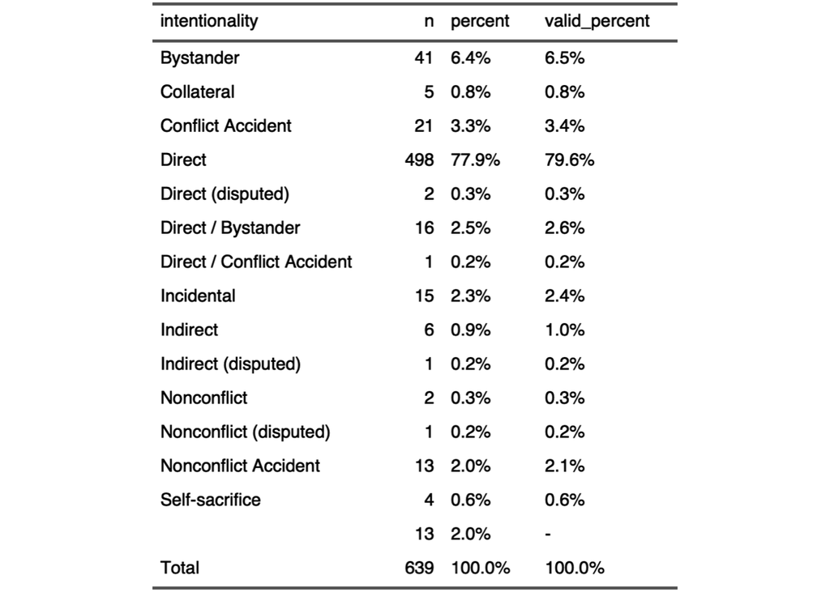

```r
ft.intention <- de %>% tabyl(intentionality)  %>%
  adorn_totals("row") %>%
  adorn_pct_formatting()

ft <- flextable(ft.intention)
ft <- autofit(ft)
plot(ft, method="webshot")
```

```r
ft.intention  %>%
 kbl() %>%
 kable_classic_2(full_width = F)
```

intentionality

n

percent

valid_percent

Bystander

41

6.4%

6.5%

Collateral

5

0.8%

0.8%

Conflict Accident

21

3.3%

3.4%

Direct

498

77.9%

79.6%

Direct (disputed)

2

0.3%

0.3%

Direct / Bystander

16

2.5%

2.6%

Direct / Conflict Accident

1

0.2%

0.2%

Incidental

15

2.3%

2.4%

Indirect

6

0.9%

1.0%

Indirect (disputed)

1

0.2%

0.2%

Nonconflict

2

0.3%

0.3%

Nonconflict (disputed)

1

0.2%

0.2%

Nonconflict Accident

13

2.0%

2.1%

Self-sacrifice

4

0.6%

0.6%

NA

13

2.0%

Total

639

100.0%

100.0%

Here’s what the human-edited text summarizing this situation looked like:

> The vast majority of conflict deaths were violent: 474 direct deaths, 38 deaths inflicted on uninvolved bystanders, and 15 more where the victim was possibly a bystander. Six people died as the indirect result of violent acts. (These combined, plus three disputed cases, comprise 536 violent deaths.) Accidents in the course of conflict claimed 21 lives. Fourteen died due to the privations of the forms of protest they (or in several cases, their adult family members) undertook. And four Bolivians sacrificed their own lives in acts of protest.

Now, we’ll work through making this producible in RMarkdown by creating variables for each of the numbers listed here:

```r
n_directdeaths <- sum(de$intentionality == "Direct", na.rm = TRUE)
n_bystander <- sum(de$intentionality == "Bystander", na.rm = TRUE)
n_directslashbystander <- sum(de$intentionality == "Direct / Bystander", na.rm = TRUE)
n_disputeddirect <- sum(de$intentionality == "Direct \\(disputed\\)", na.rm = TRUE)
n_violent <- sum(n_directdeaths, n_bystander, n_directslashbystander, n_disputeddirect)

n_conflictaccident <- sum(de$intentionality == "Conflict Accident", na.rm = TRUE)
n_indirect <- sum(de$intentionality == "Indirect", na.rm = TRUE)
n_incidental <- sum(de$intentionality == "Incidental", na.rm = TRUE)
n_selfsacrifice <- sum(de$intentionality == "Self-sacrifice", na.rm = TRUE)
```

Note that the numbers aren’t always exact matches to the original text because there has been some editing of the database since August, but we can check the correspondence between these numbers and the data table above.

### Summarizing perpetrator/victim relations…

Here’s the summary text: > Among the 536 violent deaths, we have coded the perpetrators and victims in all but seven cases (where the perpetrators are unknown). State security forces perpetrated 312 (58%) of these deaths, far more than any other group. As the alluvial diagram below shows, security forces were responsible for the vast majority of violent deaths among cocaleros, students, teachers, uncategorized protesters, and civilian bystanders, as well as a major share of deaths among miners and campesinos. Fratricidal conflict among highland indigenous communities (largely in the War of the Ayllus inter-ethnic strife in Potosí and Oruro) and miners claimed 39 and 24 lives respectively. The security forces lost 66 members to violence, half of that perpetrated by cocaleros and a quarter of this total occurring during a 2003 mutiny. Guerrillas and paramilitaries (coded as “Armed Actor”) inflicted 7 deaths (all but one upon civilians) and suffered 7 deaths at the hands of security forces.

Prior analysis of victims and perpetrators is done is Alluvial.Rmd. We’ll bring relevant parts of that script into this page, while trying to make the code as elegant as possible as we do so.

```r
## Note that this filtering appears in Alluvial.Rmd as de.violent2
intentionality.violent=str_c("Bystander",
                             "Direct", "Direct \\(disputed\\)", "Direct \\/ Bystander",
                             "Direct \\/ Conflict Accident",
                             "Indirect", "Indirect \\(disputed\\)", sep = "|")
de.violent <- de.confirmed %>% filter(str_detect(string = intentionality,
                                                 pattern=intentionality.violent))

## Turn perpetrator affiliation, deceased affiliation into factors

de.violent <- de.violent %>%
               mutate(perp_affiliation = as.factor(perp_affiliation)) %>%
               mutate(perp_affiliation = fct_explicit_na(de.violent$perp_affiliation,
                                                         na_level = "Unknown Perpetrator")) %>%
             mutate(perp_affiliation = fct_recode(perp_affiliation,
                                               "Unknown Perpetrator" = "Unknown",
                                               "Unknown Perpetrator" = "Unknown Perpetrator"))

de.violent %>% tabyl(perp_affiliation) %>% arrange(desc(n))  %>% flextable
```

| perp_affiliation | n | percent |
| --- | --- | --- |
| Security Force | 317 | 0.577413479 |
| Highland Indigenous | 44 | 0.080145719 |
| Cocalero | 38 | 0.069216758 |
| Miner | 33 | 0.060109290 |
| Partisan | 31 | 0.056466302 |
| Campesino | 18 | 0.032786885 |
| Urban Movement | 18 | 0.032786885 |
| Landowner | 17 | 0.030965392 |
| Armed Actor | 7 | 0.012750455 |
| Narcotrafficker | 6 | 0.010928962 |
| Student | 5 | 0.009107468 |
| Unknown Perpetrator | 5 | 0.009107468 |
| Disputed | 4 | 0.007285974 |
| Private Security | 2 | 0.003642987 |
| Campesinos | 1 | 0.001821494 |
| Lowland Indigenous | 1 | 0.001821494 |
| Protester | 1 | 0.001821494 |
| Santa Cruz civic committee | 1 | 0.001821494 |

```r
de.violent.unkperp <- de.violent %>%
                      filter(is.na(perp_affiliation)|(perp_affiliation=="Unknown Perpetrator"))

de.violent <- de.violent %>%
               mutate(dec_affiliation = fct_explicit_na(dec_affiliation,
                                                         na_level = "Unknown"))
de.violent %>% tabyl(dec_affiliation) %>% arrange(desc(n))  %>% flextable
```

| dec_affiliation | n | percent |
| --- | --- | --- |
| Cocalero | 98 | 0.178506375 |
| Civilian | 92 | 0.167577413 |
| Campesino | 70 | 0.127504554 |
| Security Force | 67 | 0.122040073 |
| Miner | 50 | 0.091074681 |
| Highland Indigenous | 44 | 0.080145719 |
| Protester | 41 | 0.074681239 |
| Urban Movement | 17 | 0.030965392 |
| Government Officeholder | 12 | 0.021857923 |
| Student | 12 | 0.021857923 |
| Partisan | 9 | 0.016393443 |
| Teacher | 9 | 0.016393443 |
| Armed Actor | 8 | 0.014571949 |
| Government Employee | 7 | 0.012750455 |
| Journalist | 3 | 0.005464481 |
| Lowland Indigenous | 3 | 0.005464481 |
| Landowner | 2 | 0.003642987 |
| Factory Worker | 1 | 0.001821494 |
| Narcotrafficker | 1 | 0.001821494 |
| Puerto Quijarro municipal employee | 1 | 0.001821494 |
| Transport Worker | 1 | 0.001821494 |
| Unknown | 1 | 0.001821494 |

```r
de.violent %>% tabyl(perp_affiliation, dec_affiliation, sort=TRUE) %>%
  adorn_totals(where = "col") %>%
  arrange(desc(Total)) %>%
  adorn_totals(where = "row")%>%
  flextable %>%
  add_header_lines(values = c("Deceased affilation")) %>%
  align(align = "center", part="header", i=1)
```

| Deceased affilation perp_affiliation | Deceased affilation Armed Actor | Deceased affilation Campesino | Deceased affilation Civilian | Deceased affilation Cocalero | Deceased affilation Factory Worker | Deceased affilation Government Employee | Deceased affilation Government Officeholder | Deceased affilation Highland Indigenous | Deceased affilation Journalist | Deceased affilation Landowner | Deceased affilation Lowland Indigenous | Deceased affilation Miner | Deceased affilation Narcotrafficker | Deceased affilation Partisan | Deceased affilation Protester | Deceased affilation Puerto Quijarro municipal employee | Deceased affilation Security Force | Deceased affilation Student | Deceased affilation Teacher | Deceased affilation Transport Worker | Deceased affilation Urban Movement | Deceased affilation Unknown | Deceased affilation Total |
| --- | --- | --- | --- | --- | --- | --- | --- | --- | --- | --- | --- | --- | --- | --- | --- | --- | --- | --- | --- | --- | --- | --- | --- |
| Security Force | 7 | 30 | 76 | 92 | 1 | 0 | 1 | 1 | 0 | 0 | 0 | 25 | 1 | 3 | 39 | 0 | 17 | 7 | 6 | 1 | 10 | 0 | 317 |
| Highland Indigenous | 0 | 1 | 0 | 0 | 0 | 0 | 0 | 43 | 0 | 0 | 0 | 0 | 0 | 0 | 0 | 0 | 0 | 0 | 0 | 0 | 0 | 0 | 44 |
| Cocalero | 0 | 0 | 1 | 3 | 0 | 0 | 0 | 0 | 0 | 0 | 0 | 0 | 0 | 0 | 0 | 0 | 33 | 0 | 0 | 0 | 1 | 0 | 38 |
| Miner | 0 | 4 | 0 | 0 | 0 | 0 | 1 | 0 | 1 | 0 | 0 | 23 | 0 | 0 | 0 | 0 | 4 | 0 | 0 | 0 | 0 | 0 | 33 |
| Partisan | 0 | 10 | 1 | 0 | 0 | 0 | 4 | 0 | 2 | 0 | 0 | 0 | 0 | 6 | 0 | 0 | 1 | 0 | 3 | 0 | 4 | 0 | 31 |
| Campesino | 1 | 3 | 2 | 0 | 0 | 0 | 1 | 0 | 0 | 2 | 1 | 2 | 0 | 0 | 1 | 0 | 5 | 0 | 0 | 0 | 0 | 0 | 18 |
| Urban Movement | 0 | 3 | 4 | 1 | 0 | 6 | 0 | 0 | 0 | 0 | 1 | 0 | 0 | 0 | 0 | 0 | 1 | 0 | 0 | 0 | 2 | 0 | 18 |
| Landowner | 0 | 15 | 1 | 0 | 0 | 0 | 0 | 0 | 0 | 0 | 1 | 0 | 0 | 0 | 0 | 0 | 0 | 0 | 0 | 0 | 0 | 0 | 17 |
| Armed Actor | 0 | 1 | 3 | 0 | 0 | 1 | 1 | 0 | 0 | 0 | 0 | 0 | 0 | 0 | 0 | 0 | 1 | 0 | 0 | 0 | 0 | 0 | 7 |
| Narcotrafficker | 0 | 0 | 3 | 0 | 0 | 0 | 1 | 0 | 0 | 0 | 0 | 0 | 0 | 0 | 0 | 0 | 2 | 0 | 0 | 0 | 0 | 0 | 6 |
| Student | 0 | 0 | 0 | 0 | 0 | 0 | 0 | 0 | 0 | 0 | 0 | 0 | 0 | 0 | 0 | 0 | 0 | 5 | 0 | 0 | 0 | 0 | 5 |
| Unknown Perpetrator | 0 | 0 | 0 | 1 | 0 | 0 | 3 | 0 | 0 | 0 | 0 | 0 | 0 | 0 | 0 | 0 | 0 | 0 | 0 | 0 | 0 | 1 | 5 |
| Disputed | 0 | 2 | 1 | 0 | 0 | 0 | 0 | 0 | 0 | 0 | 0 | 0 | 0 | 0 | 0 | 0 | 1 | 0 | 0 | 0 | 0 | 0 | 4 |
| Private Security | 0 | 0 | 0 | 0 | 0 | 0 | 0 | 0 | 0 | 0 | 0 | 0 | 0 | 0 | 1 | 0 | 1 | 0 | 0 | 0 | 0 | 0 | 2 |
| Campesinos | 0 | 0 | 0 | 0 | 0 | 0 | 0 | 0 | 0 | 0 | 0 | 0 | 0 | 0 | 0 | 0 | 1 | 0 | 0 | 0 | 0 | 0 | 1 |
| Lowland Indigenous | 0 | 0 | 0 | 1 | 0 | 0 | 0 | 0 | 0 | 0 | 0 | 0 | 0 | 0 | 0 | 0 | 0 | 0 | 0 | 0 | 0 | 0 | 1 |
| Protester | 0 | 1 | 0 | 0 | 0 | 0 | 0 | 0 | 0 | 0 | 0 | 0 | 0 | 0 | 0 | 0 | 0 | 0 | 0 | 0 | 0 | 0 | 1 |
| Santa Cruz civic committee | 0 | 0 | 0 | 0 | 0 | 0 | 0 | 0 | 0 | 0 | 0 | 0 | 0 | 0 | 0 | 1 | 0 | 0 | 0 | 0 | 0 | 0 | 1 |
| Total | 8 | 70 | 92 | 98 | 1 | 7 | 12 | 44 | 3 | 2 | 3 | 50 | 1 | 9 | 41 | 1 | 67 | 12 | 9 | 1 | 17 | 1 | 549 |

```r
de.vptable <- de.violent %>% tabyl(perp_affiliation, dec_affiliation, sort=TRUE)

de.vptable %>%
  flextable
```

| perp_affiliation | Armed Actor | Campesino | Civilian | Cocalero | Factory Worker | Government Employee | Government Officeholder | Highland Indigenous | Journalist | Landowner | Lowland Indigenous | Miner | Narcotrafficker | Partisan | Protester | Puerto Quijarro municipal employee | Security Force | Student | Teacher | Transport Worker | Urban Movement | Unknown |
| --- | --- | --- | --- | --- | --- | --- | --- | --- | --- | --- | --- | --- | --- | --- | --- | --- | --- | --- | --- | --- | --- | --- |
| Armed Actor | 0 | 1 | 3 | 0 | 0 | 1 | 1 | 0 | 0 | 0 | 0 | 0 | 0 | 0 | 0 | 0 | 1 | 0 | 0 | 0 | 0 | 0 |
| Campesino | 1 | 3 | 2 | 0 | 0 | 0 | 1 | 0 | 0 | 2 | 1 | 2 | 0 | 0 | 1 | 0 | 5 | 0 | 0 | 0 | 0 | 0 |
| Campesinos | 0 | 0 | 0 | 0 | 0 | 0 | 0 | 0 | 0 | 0 | 0 | 0 | 0 | 0 | 0 | 0 | 1 | 0 | 0 | 0 | 0 | 0 |
| Cocalero | 0 | 0 | 1 | 3 | 0 | 0 | 0 | 0 | 0 | 0 | 0 | 0 | 0 | 0 | 0 | 0 | 33 | 0 | 0 | 0 | 1 | 0 |
| Disputed | 0 | 2 | 1 | 0 | 0 | 0 | 0 | 0 | 0 | 0 | 0 | 0 | 0 | 0 | 0 | 0 | 1 | 0 | 0 | 0 | 0 | 0 |
| Highland Indigenous | 0 | 1 | 0 | 0 | 0 | 0 | 0 | 43 | 0 | 0 | 0 | 0 | 0 | 0 | 0 | 0 | 0 | 0 | 0 | 0 | 0 | 0 |
| Landowner | 0 | 15 | 1 | 0 | 0 | 0 | 0 | 0 | 0 | 0 | 1 | 0 | 0 | 0 | 0 | 0 | 0 | 0 | 0 | 0 | 0 | 0 |
| Lowland Indigenous | 0 | 0 | 0 | 1 | 0 | 0 | 0 | 0 | 0 | 0 | 0 | 0 | 0 | 0 | 0 | 0 | 0 | 0 | 0 | 0 | 0 | 0 |
| Miner | 0 | 4 | 0 | 0 | 0 | 0 | 1 | 0 | 1 | 0 | 0 | 23 | 0 | 0 | 0 | 0 | 4 | 0 | 0 | 0 | 0 | 0 |
| Narcotrafficker | 0 | 0 | 3 | 0 | 0 | 0 | 1 | 0 | 0 | 0 | 0 | 0 | 0 | 0 | 0 | 0 | 2 | 0 | 0 | 0 | 0 | 0 |
| Partisan | 0 | 10 | 1 | 0 | 0 | 0 | 4 | 0 | 2 | 0 | 0 | 0 | 0 | 6 | 0 | 0 | 1 | 0 | 3 | 0 | 4 | 0 |
| Private Security | 0 | 0 | 0 | 0 | 0 | 0 | 0 | 0 | 0 | 0 | 0 | 0 | 0 | 0 | 1 | 0 | 1 | 0 | 0 | 0 | 0 | 0 |
| Protester | 0 | 1 | 0 | 0 | 0 | 0 | 0 | 0 | 0 | 0 | 0 | 0 | 0 | 0 | 0 | 0 | 0 | 0 | 0 | 0 | 0 | 0 |
| Santa Cruz civic committee | 0 | 0 | 0 | 0 | 0 | 0 | 0 | 0 | 0 | 0 | 0 | 0 | 0 | 0 | 0 | 1 | 0 | 0 | 0 | 0 | 0 | 0 |
| Security Force | 7 | 30 | 76 | 92 | 1 | 0 | 1 | 1 | 0 | 0 | 0 | 25 | 1 | 3 | 39 | 0 | 17 | 7 | 6 | 1 | 10 | 0 |
| Student | 0 | 0 | 0 | 0 | 0 | 0 | 0 | 0 | 0 | 0 | 0 | 0 | 0 | 0 | 0 | 0 | 0 | 5 | 0 | 0 | 0 | 0 |
| Unknown Perpetrator | 0 | 0 | 0 | 1 | 0 | 0 | 3 | 0 | 0 | 0 | 0 | 0 | 0 | 0 | 0 | 0 | 0 | 0 | 0 | 0 | 0 | 1 |
| Urban Movement | 0 | 3 | 4 | 1 | 0 | 6 | 0 | 0 | 0 | 0 | 1 | 0 | 0 | 0 | 0 | 0 | 1 | 0 | 0 | 0 | 2 | 0 |

```r
de.violent.intercivil <- de.violent %>%
   filter(state_responsibility == "Involved" | state_responsibility == "Separate" ) %>%
   filter(perp_affiliation != "Security Force" & dec_affiliation != "Security Force")

de.vpic.table <- de.violent.intercivil %>% tabyl(perp_affiliation, dec_affiliation, sort=TRUE)

de.violent.intercivil %>% tabyl(protest_domain, sort=TRUE)
```

```
##                 protest_domain  n     percent valid_percent
##                           Coca  3 0.017045455   0.017142857
##                     Drug trade  3 0.017045455   0.017142857
##              Economic policies  1 0.005681818   0.005714286
##                      Education  5 0.028409091   0.028571429
##                      Guerrilla  4 0.022727273   0.022857143
##                          Labor  1 0.005681818   0.005714286
##              Local development  1 0.005681818   0.005714286
##                         Mining 27 0.153409091   0.154285714
##           Municipal governance 11 0.062500000   0.062857143
##              Partisan Politics 33 0.187500000   0.188571429
##                        Peasant 10 0.056818182   0.057142857
##                     Rural Land 65 0.369318182   0.371428571
##  Rural Land, Partisan Politics  2 0.011363636   0.011428571
##                     Urban land  9 0.051136364   0.051428571
##                           <NA>  1 0.005681818            NA
```

```r
de.vpic.table %>%
  flextable
```

| perp_affiliation | Armed Actor | Campesino | Civilian | Cocalero | Factory Worker | Government Employee | Government Officeholder | Highland Indigenous | Journalist | Landowner | Lowland Indigenous | Miner | Narcotrafficker | Partisan | Protester | Puerto Quijarro municipal employee | Security Force | Student | Teacher | Transport Worker | Urban Movement | Unknown |
| --- | --- | --- | --- | --- | --- | --- | --- | --- | --- | --- | --- | --- | --- | --- | --- | --- | --- | --- | --- | --- | --- | --- |
| Armed Actor | 0 | 1 | 3 | 0 | 0 | 0 | 1 | 0 | 0 | 0 | 0 | 0 | 0 | 0 | 0 | 0 | 0 | 0 | 0 | 0 | 0 | 0 |
| Campesino | 1 | 3 | 2 | 0 | 0 | 0 | 0 | 0 | 0 | 2 | 1 | 2 | 0 | 0 | 1 | 0 | 0 | 0 | 0 | 0 | 0 | 0 |
| Campesinos | 0 | 0 | 0 | 0 | 0 | 0 | 0 | 0 | 0 | 0 | 0 | 0 | 0 | 0 | 0 | 0 | 0 | 0 | 0 | 0 | 0 | 0 |
| Cocalero | 0 | 0 | 0 | 3 | 0 | 0 | 0 | 0 | 0 | 0 | 0 | 0 | 0 | 0 | 0 | 0 | 0 | 0 | 0 | 0 | 1 | 0 |
| Disputed | 0 | 2 | 1 | 0 | 0 | 0 | 0 | 0 | 0 | 0 | 0 | 0 | 0 | 0 | 0 | 0 | 0 | 0 | 0 | 0 | 0 | 0 |
| Highland Indigenous | 0 | 1 | 0 | 0 | 0 | 0 | 0 | 43 | 0 | 0 | 0 | 0 | 0 | 0 | 0 | 0 | 0 | 0 | 0 | 0 | 0 | 0 |
| Landowner | 0 | 15 | 1 | 0 | 0 | 0 | 0 | 0 | 0 | 0 | 1 | 0 | 0 | 0 | 0 | 0 | 0 | 0 | 0 | 0 | 0 | 0 |
| Lowland Indigenous | 0 | 0 | 0 | 1 | 0 | 0 | 0 | 0 | 0 | 0 | 0 | 0 | 0 | 0 | 0 | 0 | 0 | 0 | 0 | 0 | 0 | 0 |
| Miner | 0 | 4 | 0 | 0 | 0 | 0 | 0 | 0 | 1 | 0 | 0 | 23 | 0 | 0 | 0 | 0 | 0 | 0 | 0 | 0 | 0 | 0 |
| Narcotrafficker | 0 | 0 | 3 | 0 | 0 | 0 | 0 | 0 | 0 | 0 | 0 | 0 | 0 | 0 | 0 | 0 | 0 | 0 | 0 | 0 | 0 | 0 |
| Partisan | 0 | 10 | 1 | 0 | 0 | 0 | 4 | 0 | 2 | 0 | 0 | 0 | 0 | 6 | 0 | 0 | 0 | 0 | 3 | 0 | 4 | 0 |
| Private Security | 0 | 0 | 0 | 0 | 0 | 0 | 0 | 0 | 0 | 0 | 0 | 0 | 0 | 0 | 1 | 0 | 0 | 0 | 0 | 0 | 0 | 0 |
| Protester | 0 | 1 | 0 | 0 | 0 | 0 | 0 | 0 | 0 | 0 | 0 | 0 | 0 | 0 | 0 | 0 | 0 | 0 | 0 | 0 | 0 | 0 |
| Santa Cruz civic committee | 0 | 0 | 0 | 0 | 0 | 0 | 0 | 0 | 0 | 0 | 0 | 0 | 0 | 0 | 0 | 1 | 0 | 0 | 0 | 0 | 0 | 0 |
| Security Force | 0 | 0 | 0 | 0 | 0 | 0 | 0 | 0 | 0 | 0 | 0 | 0 | 0 | 0 | 0 | 0 | 0 | 0 | 0 | 0 | 0 | 0 |
| Student | 0 | 0 | 0 | 0 | 0 | 0 | 0 | 0 | 0 | 0 | 0 | 0 | 0 | 0 | 0 | 0 | 0 | 5 | 0 | 0 | 0 | 0 |
| Unknown Perpetrator | 0 | 0 | 0 | 0 | 0 | 0 | 3 | 0 | 0 | 0 | 0 | 0 | 0 | 0 | 0 | 0 | 0 | 0 | 0 | 0 | 0 | 1 |
| Urban Movement | 0 | 3 | 4 | 1 | 0 | 6 | 0 | 0 | 0 | 0 | 1 | 0 | 0 | 0 | 0 | 0 | 0 | 0 | 0 | 0 | 2 | 0 |

#### To do: Live calculate the text summary above

This data table provides enough information to calculate all the numbers in the paragaph above. Write code to do that in this chunk and then put the corresponding variables in a copy of the paragraph below it.

### Figure: Alluvial plot

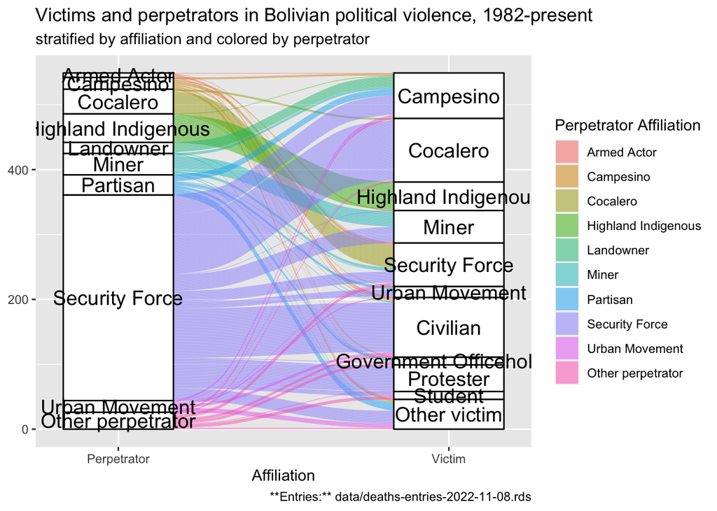

```r
def.backup <- def # For this chunk, we're going to do some temporary data processing
                        # We'll save the working dataset in a side variable, then restore it an the end

def <- de.violent # only chart the violent death

def <- def %>%
  mutate(perp_affiliation = fct_lump(perp_affiliation,
    n=9,
    other_level="Other perpetrator"
  )) # remove smallest perpetrator affiliation categories

def$dec_affiliation <- as.factor(def$dec_affiliation)

def <- def %>%
  mutate(dec_affiliation = fct_lump(dec_affiliation,
    n=10,
    other_level="Other victim"
  )) # remove smallest deceased affiliation categories

ggplot(data = def,
       aes(axis1 = perp_affiliation, axis2 = dec_affiliation)) +
  scale_x_discrete(limits = c("Perpetrator", "Victim"), expand = c(.2, .05)) +
  xlab("Affiliation") +
  geom_alluvium(aes(fill = perp_affiliation)) +
  geom_stratum() +
  geom_text(stat = "stratum", aes(label = after_stat(stratum)), size = 5, min.y = 4) +
#  theme_ipsum_rc() +
    # theme(text=element_text(family="Roboto Condensed"),
    #     legend.title=element_text(size = (3/5)*theme.size),
    #     axis.title.x=element_text(hjust=0.5, size = theme.size),
    #     axis.text.x=element_text(size = theme.size),
    #     title = element_text(hjust=0.5, size = theme.size * (8/5) )) +
  labs(fill="Perpetrator Affiliation",
       caption =datafiles_footer(es=FALSE)) +
  ggtitle("Victims and perpetrators in Bolivian political violence, 1982-present",
         "stratified by affiliation and colored by perpetrator")
```

```r
  # theme(
  #   plot.title.position = "plot",
  #   plot.caption =  element_markdown(
  #     size = 10, lineheight = 1.2, debug = TRUE
  #   )
  # )

# cat(paste(datafiles_footer(es=FALSE),"\n\n",sep=""))


def <- def.backup # restore def as it was before the alluvial plot
```

# Checking in

At this point, we have produced some summary data on the entire dataset, described levels of intentionality, defined “confirmed” deaths for purposes of analysis, and looked at perpetrators and victims for the subset of specifically ‘’violent’’ deaths. These datasets live in four separate tibbles/dataframes:

- `de.imported` is the dataset as we imported it. It has 639 entries.
- `de` is the full dataset, but has had its variables processed along the way. It has 639 entries.
- `de.confirmed` is the dataset minus our “standard exclusions”: unconfirmed deaths, and nonconflict deaths. This is the dataset we want to use for comparative analysis. It has 601 entries.
- `de.violent` is the subset of our data for violent deaths, ones in which we can meaningfully speak of a victim and perpetrator. It has 549 entries.

In our previous scripts, Graphing-Walthrough.Rmd, Graphing-Walthrough-2.Rmd, Graphing-Walthrough-3.Rmd, this is the point where we do some processing of the relevant variables to make them easier to plot and analyze. This time, I’ve moved up that code in the sectoin “Processing the variables” above.

# Continuing with “Characterizing Deaths in Bolivian Political Conflict”

We have one final paragraph

> Approaching the same question from a different perspective, we can look at how state responsibility for deaths varies across protest domain. In some arenas of protest, state violence predominates, notably the conflicts pressed by labor movements, challenges to taxation and gas privatization, and peasant movements. Conflicts over coca also center on the state, but with much more significant deadly violence levied against the state. On the other extreme, conflicts over rural land—including the Guerra de los Ayllus, struggles between large and small landowners, and lateral conflicts between claimaints to the same land—largely result in deaths among non-state actors. A similar pattern appears in many mining conflicts (and on a smaller scale, urban land disputes). Partisan political conflicts lie somewhere between.

This poragraph is a written summary of the last chart in the section, a waffle-bar chart which we’ll create here. The categorical variable on the x-axis is `protest_domain` and individual deaths are colored according to `state_responsibility`.

```r
# this very short chunk creates two simplified variables that we use for
# charts of protest_domain

de_tendomains <- de %>%
  filter(!is.na(protest_domain)) %>%
  mutate(protest_domain = fct_lump(
    protest_domain,
    n=9,
    other_level="Other domain"
  ))

def_tendomains <- def %>%
  filter(!is.na(protest_domain)) %>%
  mutate(protest_domain = fct_lump(
    protest_domain,
    n=9,
    other_level="Other domain"
  ))

                      # let's call it det for short
det <- def_tendomains # here we can choose to make either the unfiltered dataset (de)
                      # or the filtered dataset (def) into the default for our grahps
```

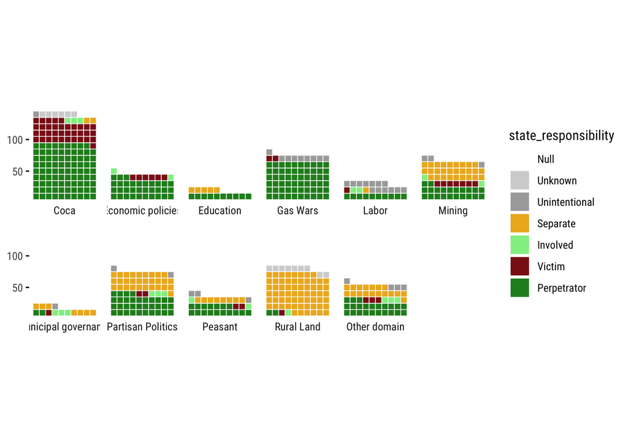

```r
library(ggthemes)
library(hrbrthemes)
library(waffle)

state_resp.colors <-  c(
  Perpetrator = "forestgreen",
  Victim = "firebrick4",
  Involved = "lightgreen",
  Separate = "goldenrod2",
  Unintentional = "darkgray",
  Unknown = "lightgray",
  Null = "white") # This null value allows us to have empty bars

# a separate list of the items appearing in the legend
state_resp.legend <-  c(
  "Perpetrator",
  "Victim",
  "Involved",
  "Separate",
  "Unintentional",
  "Unknown")

# Waffle chart
# x-axis is:       protest_domain
# fill color is:  state_responsibility
#
# x-axis variable appears twice in the code
# fill color variable appears twice in the code
#      and has a corresponding color set in scale_fill_manual

det %>%
  filter(!is.na(year)) %>%
  dplyr::count(protest_domain, state_responsibility) -> deaths_df

ggplot(deaths_df, aes(fill = state_responsibility, values = n)) +
  geom_waffle(color = "white", size = .25, n_rows = 10, flip = TRUE) +
  facet_wrap(~protest_domain, nrow = 2, strip.position = "bottom") +
  scale_x_discrete() +
  scale_y_continuous(labels = function(x) x * 10, # make this multiplyer the same as n_rows
                     expand = c(0,0)) +
  ggthemes::scale_fill_tableau(name=NULL) +
  coord_equal() +
  scale_fill_manual(values = state_resp.colors) +
  theme_minimal(base_family = "Roboto Condensed") +
  theme(panel.grid = element_blank(), axis.ticks.y = element_line()) +
  guides(fill = guide_legend(reverse = TRUE))
```

## Some other waffle charts

These don’t appear at this point in the LARR document, but I’m keeping them here for now as an allistration.

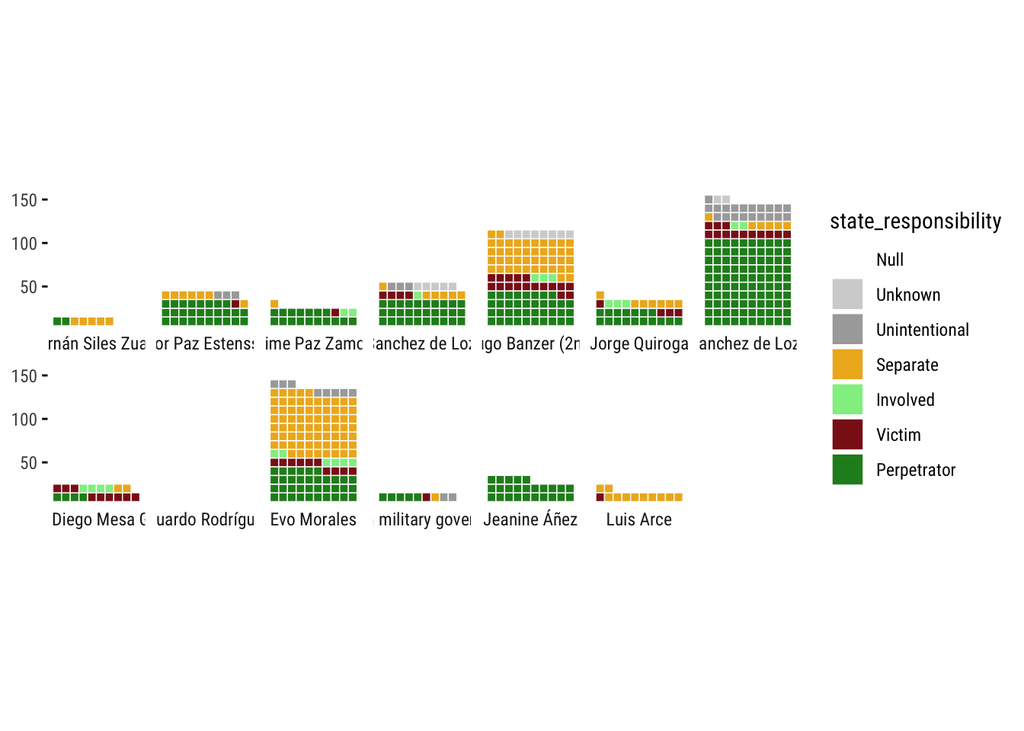

```r
library(ggthemes)
library(hrbrthemes)
library(waffle)

state_resp.colors <-  c(
  Perpetrator = "forestgreen",
  Victim = "firebrick4",
  Involved = "lightgreen",
  Separate = "goldenrod2",
  Unintentional = "darkgray",
  Unknown = "lightgray",
  Null = "white") # This null value allows us to have empty bars

# a separate list of the items appearing in the legend
state_resp.legend <-  c(
  "Perpetrator",
  "Victim",
  "Involved",
  "Separate",
  "Unintentional",
  "Unknown")

# Waffle chart
# x-axis is:      pres_admin
# fill color is:  state_responsibility
#
# x-axis variable appears twice in the code
# fill color variable appears twice in the code
#      and has a corresponding color set in scale_fill_manual

det %>%
  filter(!is.na(year)) %>%
  dplyr::count(pres_admin, state_responsibility) -> deaths_df

deaths_df <- deaths_df %>% add_row(
  pres_admin = "Eduardo Rodríguez",
  state_responsibility = "Null",
  n = 1
)

ggplot(deaths_df, aes(fill = state_responsibility, values = n)) +
  geom_waffle(color = "white", size = .25, n_rows = 10, flip = TRUE) +
  facet_wrap(~factor(pres_admin, levels=president_levels), nrow = 2, strip.position = "bottom") +
  scale_x_discrete() +
  scale_y_continuous(labels = function(x) x * 10, # make this multiplyer the same as n_rows
                     expand = c(0,0)) +
  ggthemes::scale_fill_tableau(name=NULL) +
  coord_equal() +
  scale_fill_manual(values = state_resp.colors) +
  theme_minimal(base_family = "Roboto Condensed") +
  theme(panel.grid = element_blank(), axis.ticks.y = element_line()) +
  guides(fill = guide_legend(reverse = TRUE))
```

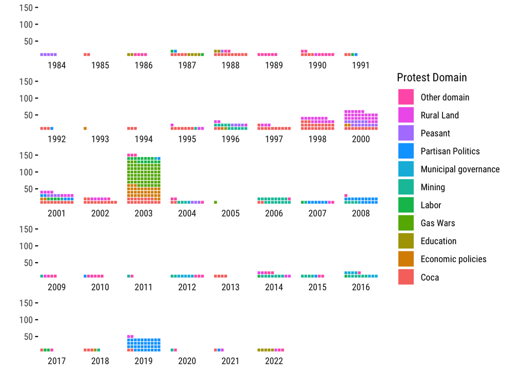

```r
# Waffle chart
# x-axis is:      year
# fill color is:  protest_domain
#
# x-axis variable appears twice in the code
# fill color variable appears twice in the code
#      and has a corresponding color set in scale_fill_manual

det %>%
  filter(!is.na(year)) %>%
  dplyr::count(year, protest_domain) -> deaths_df

ggplot(deaths_df, aes(fill = protest_domain, values = n)) +
  geom_waffle(color = "white", size = .25, n_rows =10, flip = TRUE) +
  facet_wrap(~year, ncol = 8, strip.position = "bottom") +
  scale_x_discrete() +
  scale_y_continuous(labels = function(x) x * 10, # make this multiplyer the same as n_rows
                     expand = c(0,0)) +
  scale_fill_discrete(name="Protest Domain",
                    guide = guide_legend(reverse=TRUE)) +  coord_equal() +
  theme_minimal(base_family = "Roboto Condensed") +
  theme(panel.grid = element_blank(), axis.ticks.y = element_line()) +
  guides(fill = guide_legend(reverse = TRUE))
```

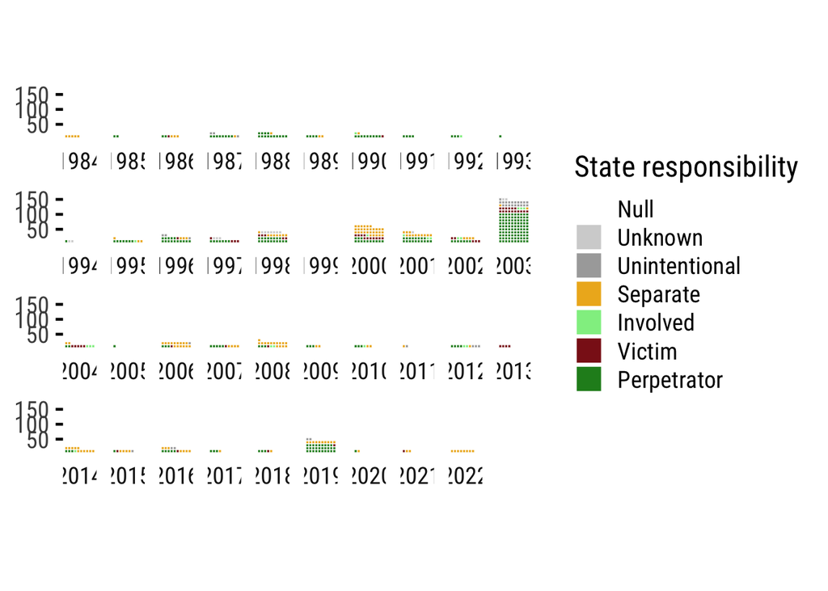

```r
# Waffle chart
# x-axis is:      year
# fill color is:  protest_domain
#
# x-axis variable appears twice in the code
# fill color variable appears twice in the code
#      and has a corresponding color set in scale_fill_manua
# We're adding a single white block to the year 1999, which had no deaths.

det %>%
  #  filter(year >= 1990) %>%
  filter(!is.na(year)) %>%
  dplyr::count(year, state_responsibility) -> deaths_df

deaths_df <- deaths_df %>% add_row(
  year = 1999,
  state_responsibility = "Null",
  n = 1
)

ggplot(deaths_df, aes(fill = state_responsibility, values = n)) +
  geom_waffle(color = "white", size = .25, n_rows = 10, flip = TRUE) +
  facet_wrap(~year, ncol = 10, strip.position = "bottom") +
  scale_x_discrete() +
  scale_y_continuous(labels = function(x) x * 10, # make this multiplyer the same as n_rows
                     expand = c(0,0)) +
  coord_equal() +
  scale_fill_manual(values = state_resp.colors,
  #                   limits = state_resp.legend,  # this set should exclude null from the legend,
                                                   # but it makes it dark grey at the same time
                    name="State responsibility",
                    guide = guide_legend(reverse=TRUE)) +
  theme_minimal(base_family = "Roboto Condensed", base_size=18) +
  theme(panel.grid = element_blank(), axis.ticks.y = element_line(),
        axis.title = element_text(size = 24))
```

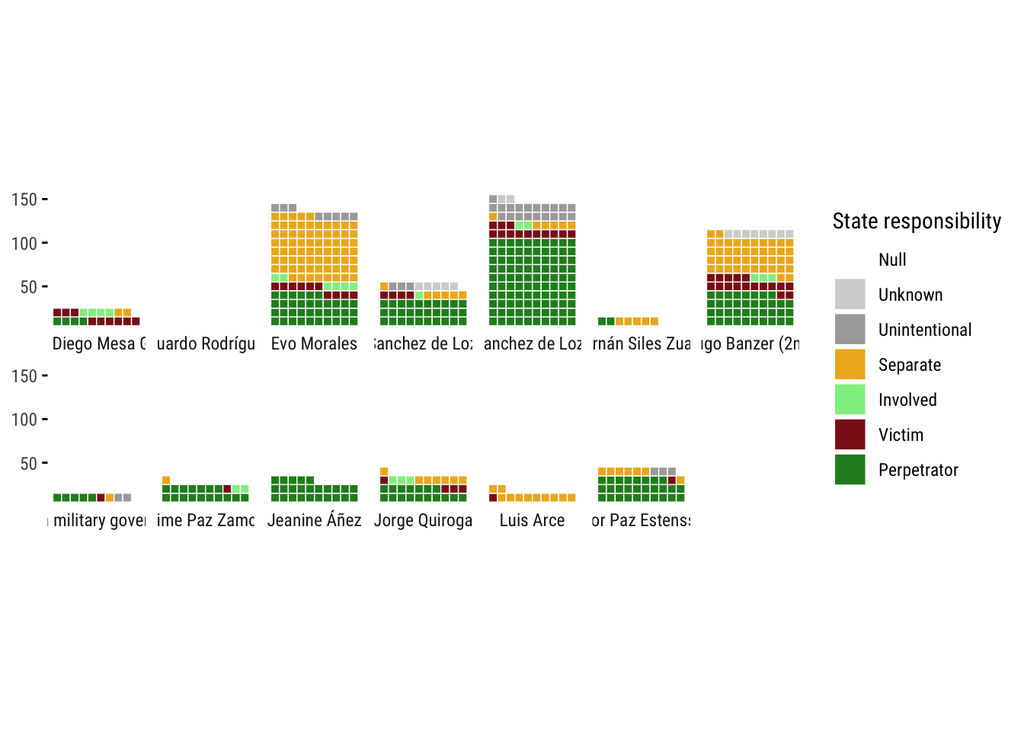

```r
det %>%
  #  filter(year >= 1990) %>%
  filter(!is.na(year)) %>%
  dplyr::count(pres_admin, state_responsibility) -> deaths_df

deaths_df <- deaths_df %>% add_row(
  pres_admin = "Eduardo Rodríguez",
  state_responsibility = "Null",
  n = 1
)

ggplot(deaths_df, aes(fill = state_responsibility, values = n)) +
  geom_waffle(color = "white", size = .25, n_rows = 10, flip = TRUE) +
  facet_wrap(~pres_admin, nrow = 2, strip.position = "bottom") +
  coord_equal() +
  scale_x_discrete() +
  scale_y_continuous(labels = function(x) x * 10, # make this multiplyer the same as n_rows
                     expand = c(0,0)) +
  scale_fill_manual(values = state_resp.colors,
                    name="State responsibility",
                    guide = guide_legend(reverse=TRUE)) +
  theme_minimal(base_family = "Roboto Condensed") +
  theme(panel.grid = element_blank(), axis.ticks.y = element_line()) +
  guides(fill = guide_legend(reverse = TRUE))
```

[figure not shown]

```r
# Waffle chart
# State responsibility for deaths in the largest events
#
# x-axis is:      event_title
# fill color is:  state_responsibility
#
# x-axis variable appears twice in the code
# fill color variable appears twice in the code
#      and has a corresponding color set in scale_fill_manual
#
# Our dataset is created by filtering out by event size (det.events)
# then counting by our axes as usual
# then creating a new variable in deaths_df that counts the number of deaths per event
# finally, we use n_event to order the facets of our chart

det.events <- det %>% group_by(event_title) %>% filter(n()>4)

det.events %>%
  #  filter(year >= 1990) %>%
  filter(!is.na(year)) %>%
  dplyr::count(event_title, state_responsibility) -> deaths_df

deaths_df %>%
  group_by(event_title) %>%
  mutate(n_event = sum(n)) -> deaths_df

n_events_deaths_df <- nrow(unique(deaths_df$event_title))

ggplot(deaths_df, aes(fill = state_responsibility, values = n)) +
  geom_waffle(color = "white", size = .25, n_rows = 10, flip = TRUE) +
  facet_wrap(~fct_reorder(event_title, n_event, .desc = TRUE),
             ncol = 5, strip.position = "bottom",
             labeller = label_wrap_gen(20)) +
  scale_x_discrete() +
  scale_y_continuous(labels = function(x) x * 10, # make this multiplyer the same as n_rows
                     expand = c(0,0)) +
  scale_fill_manual(values = state_resp.colors,
                    limits = state_resp.legend, # this gets rid of the irrelevant Null
                    name="State responsibility",
                    guide = guide_legend(reverse=TRUE)) +  coord_equal() +
  theme_minimal(base_family = "Roboto Condensed", base_size=16) +
  theme(panel.grid = element_blank(), axis.ticks.y = element_line(),
        axis.title = element_text(size = 18)) +
  ggtitle("Deadliest events in Bolivian political, 1982-present",
         "Ordered by size of event and colored by state responsibility")
```

```r
# Note: We've changed the facet_wrap variable to:
# ~fct_reorder(event_title, n_event, .desc = TRUE)
# This sorts the events by the number of deaths
```